# Vikash’s cazymes analysis

Nicolas Delhomme & Vikash Kummar

2018-03-29

# 1 Setup

Set the working dir

```r
setwd("/mnt/picea/projects/aspseq/emellerowicz/Cazymes")
```

Load libraries

```r
suppressPackageStartupMessages(library(DESeq2))
suppressPackageStartupMessages(library(dplyr))
suppressPackageStartupMessages(library(gplots))
suppressPackageStartupMessages(library(hyperSpec))
suppressPackageStartupMessages(library(matrixStats))
suppressPackageStartupMessages(library(pander))
suppressPackageStartupMessages(library(RColorBrewer))
suppressPackageStartupMessages(library(tibble))
suppressPackageStartupMessages(library(vsn))
```

Source helpers

```r
source("~/Git/UPSCb/src/R/expressionSpecificityUtility.R")
source("~/Git/UPSCb/src/R/featureSelection.R")
source("~/Git/UPSCb/src/R/plot.multidensity.R")
```

palette

```r
pal <- brewer.pal(8,"Dark2")
cpal <- rainbow(23)
#  brewer.pal(11,"Paired")
hpal <- colorRampPalette(c("blue","white","red"))(100)
hpal10 <- colorRampPalette(c("blue","white","red"))(10)

# read cazymes IDs
cazymes<- read.delim("~/Git/UPSCb/projects/aspen-cazymes/src/R/cazyid.txt",
                     sep="\t",header=TRUE,stringsAsFactors = FALSE,
                     blank.lines.skip=TRUE)[,1]
```

# 2 Data

## 2.1 Set up

### 2.1.1 exAtlas

```r
dds <- DESeqDataSetFromHTSeqCount(
  data.frame(
    sampleName=sub("\\.txt","",dir("HTSeq",pattern="R[0-9]{1,2}\\.txt")),
    sampleFile=dir("HTSeq",pattern="R[0-9]{1,2}\\.txt"),
    condition=sub("\\.txt","",dir("HTSeq",pattern="R[0-9]{1,2}\\.txt"))
  ),directory="HTSeq",
  design=~condition)
```

the sample data

```r
catalog.sample <- read.csv("~/Git/UPSCb/projects/aspseq/doc/asp201-samples.csv")
catalog.sample <- catalog.sample[catalog.sample$RNA.label %in% colnames(dds),]
```

subset the dds

```r
dds <- dds[,match(as.character(catalog.sample$RNA.label),colnames(dds))]
samples <- catalog.sample[,c("RNA.label","TSample")]
colnames(samples) <- c("SampleID","Tissue")
```

Keep only a subset of samples

```r
#keep <- c("R3","R12","R15","R22","R18","R24","R13","R4","R9","R7","R8","R16","R11","R20","R10","R1")
drop <- c("R17","R19","R23")
```

Just to validate

```r
sel <- !catalog.sample$RNA.label %in% drop
cs <- catalog.sample[sel,]
pander(cs)
```

Table continues below

|  | TSample | Condition | Location | Sample.date | RNA.label |
| --- | --- | --- | --- | --- | --- |
| **1** | Twigs | Non-Girdled | SLU | 10/07/30 | R1 |
| **2** | Flowers | Dormant | SLU | 10/05/03 | R2 |
| **3** | Leaves | Drought | Greenhouse | 10/07/30 | R3 |
| **4** | Flowers | Expanded | SLU | 10/05/30 | R4 |
| **5** | Leaves | Beetle-Damaged | Lab | 10/08/05 | R5 |
| **6** | Leaves | Mechanical-Damage | Greenhouse | 10/08/05 | R6 |
| **7** | Leaves | Mature | SLU | 10/08/03 | R7 |
| **8** | Leaves | Mature-2 | SLU | 10/07/30 | R8 |
| **9** | Flowers | Expanding | SLU | 10/05/18 | R9 |
| **10** | Suckers | Whole-Sucker | SLU | 10/08/05 | R10 |
| **11** | Petiole | Mature | SLU | 10/07/30 | R11 |
| **12** | Leaves | Undamaged | Greenhouse | 10/08/05 | R12 |
| **13** | Buds | Pre-chilling | SLU | 10/07/30 | R13 |
| **14** | Buds | Dormant | SLU | 10/05/03 | R14 |
| **15** | Leaves | Drought-2 | Greenhouse | 10/07/30 | R15 |
| **16** | Leaves | Freshly-Expanded | SLU | 10/05/25 | R16 |
| **18** | Roots | Control | Greenhouse | 10/07/30 | R18 |
| **20** | Seeds | Mature | SLU | 10/06/21 | R20 |
| **21** | Leaves | Young-Expanding | SLU | 10/05/18 | R21 |
| **22** | Leaves | Control | Greenhouse | 10/07/30 | R22 |
| **24** | Roots | Drought | Greenhouse | 10/07/30 | R24 |

Table continues below

|  | RIN | ng.ul | A260.280 | A260.230 | ug.yield | ul.pool1 | ul.pool2 |
| --- | --- | --- | --- | --- | --- | --- | --- |
| **1** | 8.7 | 332.1 | 2.19 | 2.33 | 19.9 | 0.6 | 1.3 |
| **2** | 8.6 | 884.3 | 2.2 | 2.4 | 53.1 | 0.2 | 0.5 |
| **3** | 8.3 | 623 | 2.19 | 2.37 | 37.4 | 0.3 | 0.7 |
| **4** | 8.5 | 288.9 | 2.2 | 2.34 | 17.3 | 0.7 | 1.4 |
| **5** | 8.3 | 269.4 | 2.2 | 2.36 | 16.2 | NA | 1.5 |
| **6** | 8.2 | 533.2 | 2.16 | 2.17 | 32 | 0.4 | 0.8 |
| **7** | 8.2 | 350.5 | 2.18 | 2.3 | 21 | 0.6 | 1.2 |
| **8** | 8 | 490.1 | 2.11 | 1.8 | 29.4 | 0.4 | 0.9 |
| **9** | 8.3 | 475 | 2.17 | 2.33 | 28.5 | 0.4 | 0.9 |
| **10** | 8.4 | 776.7 | 2.2 | 2.38 | 46.6 | 0.3 | 0.5 |
| **11** | 8.7 | 203.7 | 2.21 | 2.3 | 12.2 | 1 | 2 |
| **12** | 8.3 | 603.2 | 2.21 | 2.38 | 36.2 | 0.3 | 0.7 |
| **13** | 8.2 | 344.6 | 2.17 | 2.32 | 20.7 | 0.6 | 1.2 |
| **14** | 8.5 | 609.8 | 2.2 | 2.39 | 36.6 | 0.3 | 0.7 |
| **15** | 8.2 | 632.1 | 2.18 | 2.36 | 37.9 | 0.3 | 0.7 |
| **16** | 8.3 | 1171 | 2.19 | 2.4 | 70.2 | 0.2 | 0.4 |
| **18** | 8.1 | 272.4 | 2.19 | 2.34 | 16.3 | 0.8 | 1.5 |
| **20** | 7.9 | 238.9 | 2.21 | 2.3 | 14.3 | 0.9 | 1.7 |
| **21** | 8.3 | 2239 | 2.17 | 2.38 | 134.3 | 0.1 | 0.2 |
| **22** | 8.3 | 526.6 | 2.21 | 2.28 | 31.6 | 0.4 | 0.8 |
| **24** | 8.1 | 133 | 2.22 | 2.22 | 8 | NA | 3.1 |

|  | ug.remaining.yield |
| --- | --- |
| **1** | 19.3 |
| **2** | 52.4 |
| **3** | 36.8 |
| **4** | 16.7 |
| **5** | 15.7 |
| **6** | 31.4 |
| **7** | 20.4 |
| **8** | 28.8 |
| **9** | 27.9 |
| **10** | 46 |
| **11** | 11.6 |
| **12** | 35.6 |
| **13** | 20 |
| **14** | 36 |
| **15** | 37.3 |
| **16** | 69.6 |
| **18** | 15.7 |
| **20** | 13.7 |
| **21** | 133.7 |
| **22** | 31 |
| **24** | 7.6 |

```r
dds <- dds[,sel]
samples <- samples[sel,]

samples$Tissue <- paste(cs$TSample,
                        sub("-","_",sub("Drought-2","Drought",cs$Condition)),
                        cs$Location,sep="_")
```

#### 2.1.1.1 Normalisation

```r
colData(dds)$tissue <- factor(samples$Tissue)
design(dds) <- ~tissue
vsd <- varianceStabilizingTransformation(dds,blind = FALSE)
vst <- assay(vsd)
vst <- vst - min(vst)
```

The mean-sd relationship is as expected (slightly higher sd where most genes are expressed; i.e. at the average depth of sequencing). The higher sd is unsurprising given the fact we look at many different tissues and conditions

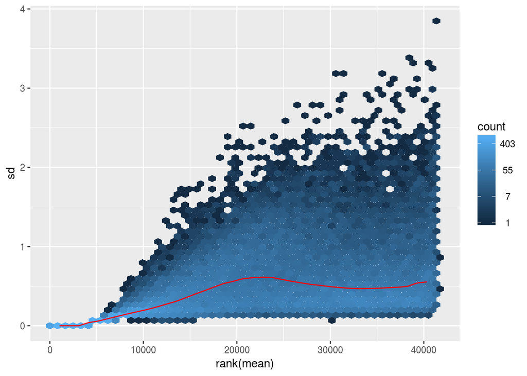

```r
meanSdPlot(vst)
```

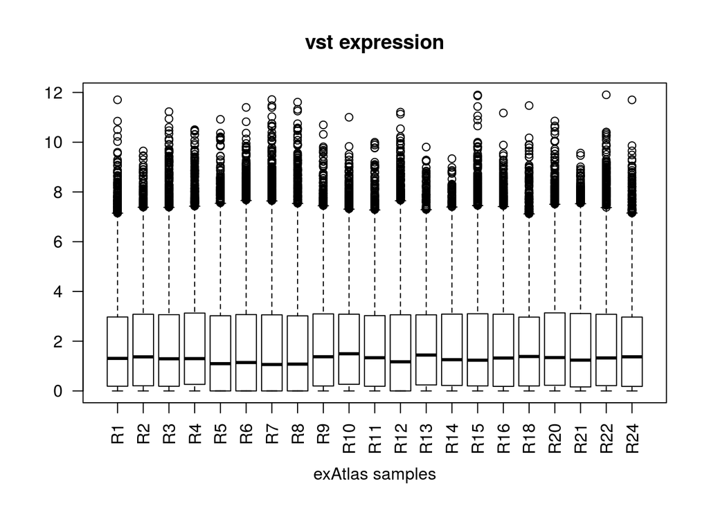

```r
boxplot(vst,main="vst expression",las=2,xlab="exAtlas samples")
```

### 2.1.2 Immanen et al.

```r
wood.vst <- read.csv(file="../../facility/PRJEB13583/Potri03/analysis/HTSeq/library-size-normalized_variance-stabilized_PRJEB13583_ctl-selected_frc_expression-effect-corrected-data.csv",
                     row.names=1)
wood.sample <- read.csv("~/Git/UPSCb/projects/facility-immanen-et-al/doc/PRJEB13583-Ctl-bestaligned frc.csv")
wood.sample$othernames <- sprintf("AF%02d",as.integer(sub("AF","",wood.sample$othernames)))
```

Add the tissue description

```r
wood.sample$Tissue <- "Xylem"
wood.sample$Tissue[wood.sample$othernames %in% c("AF01","AF02","AF03")] <- "Phloem"
wood.sample$Tissue[wood.sample$othernames %in% c("AF04","AF05","AF06")] <- "Cambium"
```

### 2.1.3 Median centering

#### 2.1.3.1 Merge

```r
merge.vst <- column_to_rownames(full_join(
  rownames_to_column(as.data.frame(vst)),
                  rownames_to_column(wood.vst),
                  by="rowname"))

nona.vst <- merge.vst
nona.vst[is.na(nona.vst)] <- 0
```

#### 2.1.3.2 Visualisation

How do the datasets look like

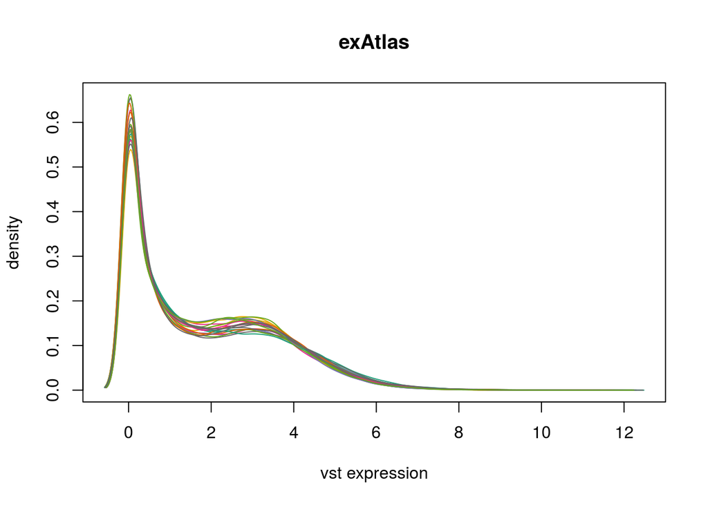

```r
plot.multidensity(lapply(1:ncol(vst),function(i){vst[,i]}),
                  col = sample(pal,size=ncol(vst),replace = TRUE),
                  xlab="vst expression", main="exAtlas")
```

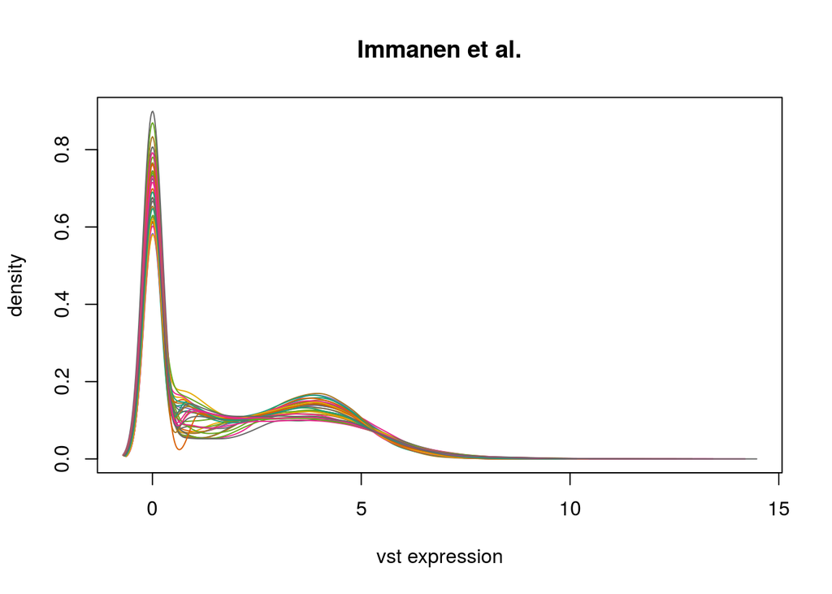

```r
plot.multidensity(lapply(1:ncol(wood.vst),function(i){wood.vst[,i]}),
                  col = sample(pal,size=ncol(wood.vst),replace = TRUE),
                  xlab="vst expression", main="Immanen et al.")
```

and in combination

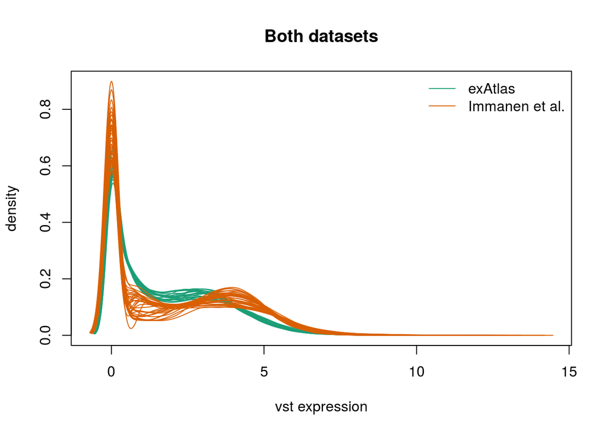

```r
plot.multidensity(lapply(1:ncol(merge.vst),
                         function(i,v){nona.vst[,i]}),
                  col = rep(pal[1:2],c(ncol(vst),ncol(wood.vst))),
                  xlab="vst expression", main="Both datasets",
                  legend.x = "topright",legend.col = pal[1:2],
                  legend = c("exAtlas","Immanen et al."))
```

#### 2.1.3.3 Centering

To ensure a proper centering, we replace 0s by NA

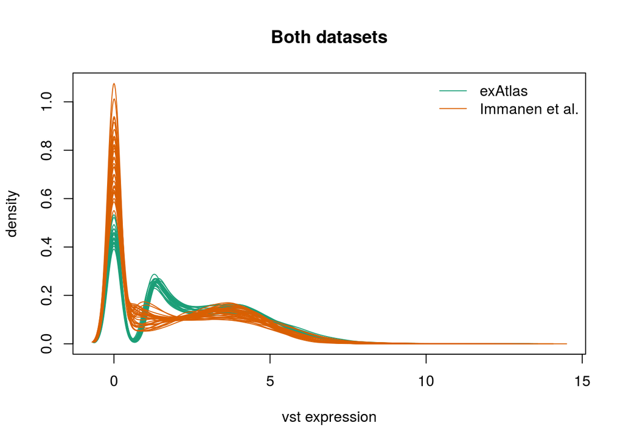

```r
merge.vst[merge.vst==0] <- NA
cent.vst <- t(t(merge.vst) - colMedians(as.matrix(merge.vst),na.rm = TRUE))
cent.vst <- cent.vst + abs(min(cent.vst,na.rm = TRUE))
nona.cent.vst <- cent.vst
nona.cent.vst[is.na(nona.cent.vst)] <- 0

plot.multidensity(lapply(1:ncol(merge.vst),
                         function(i,v){nona.cent.vst[,i]}),
                  col = rep(pal[1:2],c(ncol(vst),ncol(wood.vst))),
                  xlab="vst expression", main="Both datasets",
                  legend.x = "topright",legend.col = pal[1:2],
                  legend = c("exAtlas","Immanen et al."))
```

## 2.2 Expression specificity

```r
sprintf("There are %s cazymes left in the dataset",
        sum(cazymes %in% sub("\\.0$","",rownames(cent.vst))))
```

```
## [1] "There are 1870 cazymes left in the dataset"
```

```r
tissue.spec <- expressionSpecificity(exp.mat = cent.vst,
                                     tissues = c(as.character(samples$Tissue),
                                     wood.sample$Tissue),
                                     mode = "local",
                                     output = "complete")
```

```
## Calculating tissue specificity
```

Most genes are ubiquitous (closer to 0) but some are more specific to a given tissue (close to 1)

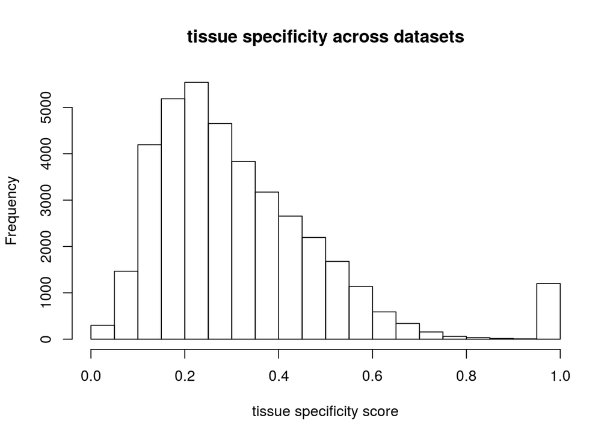

```r
hist(tissue.spec[,"score"],xlab="tissue specificity score",
     main="tissue specificity across datasets")
```

### 2.2.1 cazymes

```r
caz.t.spc <- tissue.spec[sub("\\.0$","",rownames(tissue.spec)) %in% cazymes,]
```

This looks similar for the cazymes

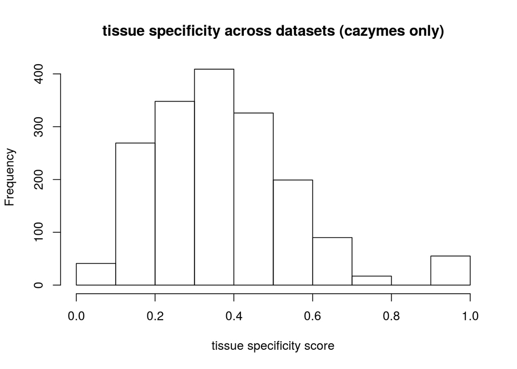

```r
hist(caz.t.spc[,"score"],xlab="tissue specificity score",
     main="tissue specificity across datasets (cazymes only)")
```

Most cazymes are expressed in all tissues but some seem specific to the woody tissues (keep in mind the apparent limitation of the Immanen et al. data)

```r
pander(table(rowSums(is.na(caz.t.spc[,2:(ncol(caz.t.spc)-2)]))))
```

Table continues below

| 0 | 1 | 2 | 3 | 4 | 5 | 6 | 7 | 8 | 9 | 10 | 11 | 12 | 13 | 14 | 15 |
| --- | --- | --- | --- | --- | --- | --- | --- | --- | --- | --- | --- | --- | --- | --- | --- |
| 926 | 83 | 84 | 82 | 47 | 41 | 39 | 28 | 27 | 24 | 28 | 21 | 15 | 17 | 24 | 28 |

| 16 | 17 | 18 | 19 | 20 | 21 | 22 | 23 |
| --- | --- | --- | --- | --- | --- | --- | --- |
| 21 | 25 | 32 | 31 | 36 | 41 | 54 | 116 |

The cazymes appear slightly more tissue specific that all genes

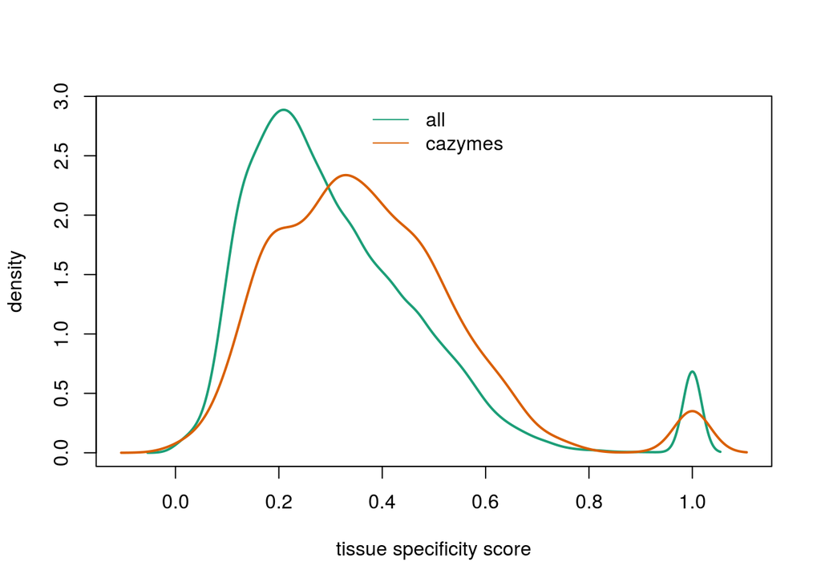

```r
a.sel <- !is.na(tissue.spec[,"score"])
c.sel <- !is.na(caz.t.spc[,"score"])
plot.multidensity(list(all=tissue.spec[a.sel,"score"],
                       cazymes=caz.t.spc[c.sel,"score"]),
                       col=pal[1:2],xlab="tissue specificity score",
                  lwd=2)
```

The difference in the means is small but significant

```r
t.test(tissue.spec[! rownames(tissue.spec) %in% rownames(caz.t.spc),"score"],caz.t.spc[,"score"])
```

```
##
##  Welch Two Sample t-test
##
## data:  tissue.spec[!rownames(tissue.spec) %in% rownames(caz.t.spc),  and caz.t.spc[, "score"]    "score"] and caz.t.spc[, "score"]
## t = -12.774, df = 1930, p-value < 2.2e-16
## alternative hypothesis: true difference in means is not equal to 0
## 95 percent confidence interval:
##  -0.06708884 -0.04923043
## sample estimates:
## mean of x mean of y
## 0.3154833 0.3736430
```

### 2.2.2 Ordering

```r
dat <- apply(tissue.spec[,2:(ncol(caz.t.spc)-2)] == tissue.spec[,"maxn"],1,which)
```

We need to handle the cases were we have NA

```r
exp.peak <- colnames(tissue.spec[,2:(ncol(caz.t.spc)-2)])[sapply(dat,"[",1)]

ord <- order(exp.peak,(1-tissue.spec[,"score"]))

caz.peak <- exp.peak[sub("\\.0$","",rownames(tissue.spec)) %in% cazymes]
caz.ord <- order(caz.peak,
                 (1-caz.t.spc [,"score"]))
```

Export

```r
write.csv(cbind(tissue.spec,exp.peak)[ord,],
          file="All_vst-expression-data_expression-specificity-order.csv")
```

Export

```r
write.csv(cbind(caz.t.spc,caz.peak)[caz.ord,],
          file="cazymes-tissue-specificity.csv")
```

# 3 Heatmaps

## 3.1 Expression values

### 3.1.1 Z-score, pearson distance, ward correlation

Here we need to keep in mind that both datasets are not immediately comparable

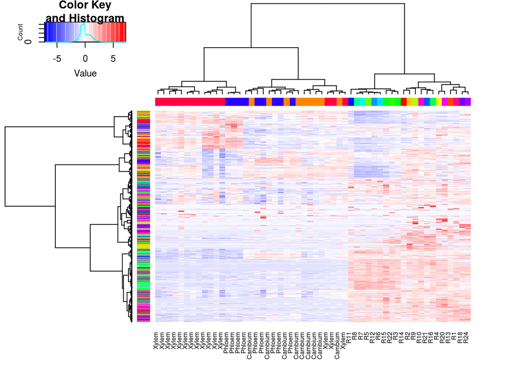

```r
sel <- sub("\\.0$","",rownames(nona.cent.vst)) %in% cazymes
dat <- nona.cent.vst[sel,]
s.dat <- t(scale(t(dat)))
n.sel <- rowSums(is.na(s.dat)) != ncol(s.dat)
heatmap.2(s.dat[n.sel,],distfun = pearson.dist,
          hclustfun = function(X){hclust(X,method = "ward.D")},
          ColSideColors = cpal[as.integer(factor(c(as.character(samples$Tissue),
                                                  wood.sample$Tissue)))],
          RowSideColors = cpal[as.integer(factor(exp.peak[sel][n.sel]))],
          trace="none",col=hpal,labRow = NA,labCol = c(as.character(samples$SampleID),
                                                         wood.sample$Tissue))
```

## 3.2 Tissue specificity

```r
caz.prop <- caz.t.spc[,2:(ncol(caz.t.spc)-2)]/rowSums(caz.t.spc[,2:(ncol(caz.t.spc)-2)],na.rm=TRUE)
caz.prop[is.na(caz.prop)] <- 0
```

Most cazymes are ubiquitously expressed but some are tissue specific, obviously in the wood tissue, but also in the seeds

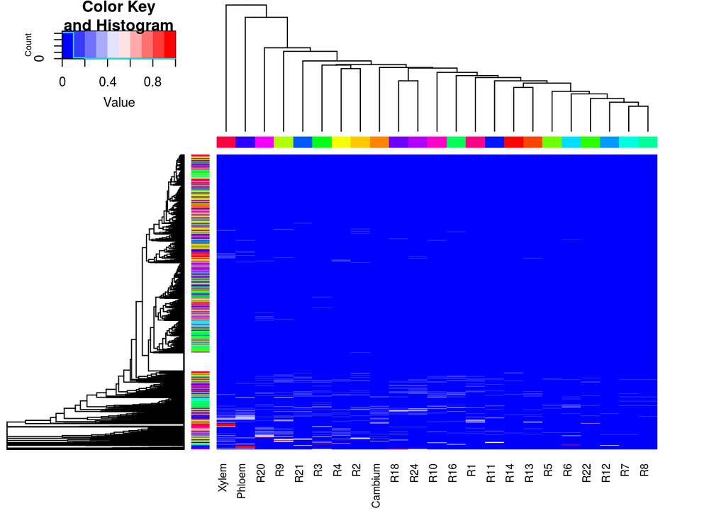

```r
labels <- colnames(caz.t.spc)[2:(ncol(caz.t.spc)-2)]
newLabs <- as.character(samples$SampleID)[match(labels,samples$Tissue)]
labels[!is.na(newLabs)] <- newLabs[!is.na(newLabs)]

heatmap.2(caz.prop[caz.ord,],trace="none",
          ColSideColors = cpal[as.integer(factor(colnames(caz.t.spc)[2:(ncol(caz.t.spc)-2)]))],
          RowSideColors = cpal[as.integer(factor(caz.peak[caz.ord]))],
          labCol = labels,col=hpal10,
          labRow = NA)
```